# EMP Benthic Data Analysis

Christina Burdi

11/30/2021

Benthic sampling includes both clam and amphipod data that we’re interested in.

Redoing benthic script with correct stations that were continuously monitored over the time series

Load packages

# Download benthic data if it’s not already found locally in the data_raw folder

```r
if(!file.exists(file.path("data_raw", "DWR Benthic raw count data 1975-2020.csv"))){
  if(!dir.exists("data_raw")){
    dir.create("data_raw")
  }
  timeout<-getOption('timeout')
  options(timeout=300)
  download.file("https://portal.edirepository.org/nis/dataviewer?packageid=edi.1036.1&entityid=e65a3e7da08744a8cd6114d4e5f78c53", method = "libcurl",
                destfile=file.path("data_raw", "DWR Benthic raw count data 1975-2020.csv"))
  options(timeout=timeout)
}
```

# Clean and reprocess data

Read in amphipod biomass conversion data

```r
amphipod_biomass<-read_csv("data/data_in/amphipod_biomass_conversions.csv")%>%
  select(SpeciesName, Month, Biomass_mean)
```

Read in raw benthic count data

Benthic file does not exist locally so can get it from KMB: https://knb.ecoinformatics.org/knb/d1/mn/v2/object/urn:uuid:25b7befd-e931-4a50-9bf6-14715561f64a

- Benthic survey used to sample on the L, R, or C of a site location historically, and eventually picked a side to monitor continuously, so need to remove the “Left, Right, Center” from the station names so can combine sites over the years.
- Want to make sure that we use all of the data from that site, despite which side it was sampled on
- Still want to keep A as a station designation
- Create a monthly time step to see which stations were sampled continuously over the years
- Take mean of lat/ long for each site since some sites moved slightly over the years based on the L, R, C

```r
ben <- read.csv("data_raw/DWR Benthic raw count data 1975-2020.csv")  %>%
  filter(Genus %in% c("Potamocorbula", "Corbicula", "Ampelisca",
                      "Monocorophium", "Sinocorophium", "Americorophium",
                      "Crangonyx", "Gammarus", "Hyalella"))%>%
  select(SampleDate, Year, Month, StationCode, Grab, OrganismCode, Count, Order_level, Genus, Latitude, Longitude)%>%
  mutate(mon = ym(paste0(Year, Month, sep = "-")), #create a month time step
         CPUE=Count/0.052,
         Month=month(mon))%>%
  left_join(amphipod_biomass, by=c("Genus"="SpeciesName", "Month"))%>%
  mutate(BPUE=CPUE*Biomass_mean)%>%
  select(-Biomass_mean)%>%
  group_by(across(-c(Count, Grab, CPUE, BPUE)))%>%
  summarise(across(c(CPUE, BPUE), mean), .groups="drop")%>%
  mutate(Latitude=if_else(StationCode=="D7-C", 38.1171292, Latitude),
         Longitude=if_else(StationCode=="D7-C", -122.0395539, Longitude))
```

# Graph which stations were sampled continuously over the time series

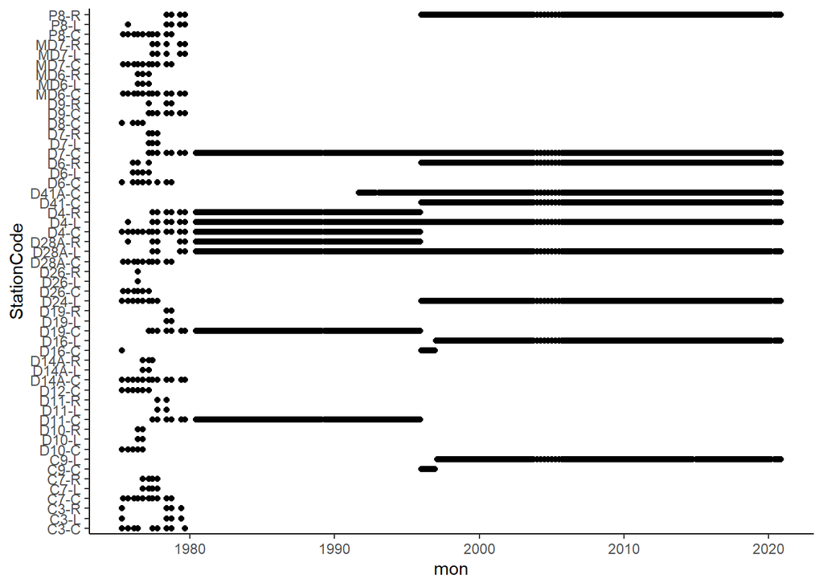

```r
#sites and number of months sampled to look at which were sampled continuously for analysis

sites_mon <- ben  %>%
  distinct(StationCode, Latitude, Longitude, mon)

#graph of monthly sampling of each site over the time series

ggplot(sites_mon, aes(x = mon, y = StationCode), size = 3) +
  geom_point() +
  theme_classic()
```

Additional stations picked up in the late 1990s

May want to eliminate clams from annual analysis based on small coverage with just those 3 sites, or combine sites close together. Need to explore.

# Map of sites colored with stations sampled continuously from 1980s, and 1990s. Scaled by months sampled

First specify which stations are from the 1980s and which are from the 1990s

```r
#stations sampled continuously since the 1980s

ben_1980 = c("D7-C",
             "D4-L",
             "D28A-L")

#stations sampled continuously since the 1990s

ben_1990 = c("P8-R",
             "D6-R",
             "D41-C",
             "D41A-C",
             "D24-L",
             "D16-L",
             "C9-L")
```

# Map of all stations

- Red = sites sampled continuously from the 1980s
- Blue = from the 1990s
- Black = sites not sampled continuously

```r
sites <- ben %>%
  group_by(StationCode, Latitude, Longitude) %>%
  summarise(n_months = length(unique(mon)), .groups  =  "drop")

leaflet(sites) %>%
  addTiles() %>% #adds the default base map
  addCircleMarkers(data= sites, #all benthic sites
                   lat = ~Latitude,
                   lng = ~Longitude,
                   label = ~StationCode,
                   radius = ~n_months/ 50, #arbitrary scaling to show number of months each site was sampled
                   color = "black",
                   fillColor = "black",
                   weight = 0.25,
                   fillOpacity = 1) %>%
  addCircleMarkers(data = sites %>% filter(StationCode %in% ben_1980), #sites continuously from the 1980s
                   lat = ~Latitude,
                   lng = ~Longitude,
                   label = ~StationCode,
                   radius = ~n_months/ 50,
                   color = "black",
                   fillColor = "red",
                   weight = 0.25,
                   fillOpacity = 1) %>%
  addCircleMarkers(data = sites %>% filter(StationCode %in% ben_1990), #sites from the 1990s
                   lat = ~Latitude,
                   lng = ~Longitude,
                   label = ~StationCode,
                   radius = ~n_months/ 50,
                   color = "black",
                   fillColor = "blue",
                   weight = 0.25,
                   fillOpacity = 1)
```

[interactive chart not shown]

# Calculate summarised CPUE

- Do all critters first and then filter out later for what we want
- Benthic CPUE (organisms/ m2) = (Sum of organisms per visit/ # of grabs per visit)/ (0.052 grabs/ m2)
- Do CPUE with 1980 stations first for annual analysis. Need to explore other stations that we might need to combine to expand spatial coverage for annual data
- Calculate average CPUE for
- 1. Clam and Amphipod Annual w/o Regions
- 2. Clam and Amphipod Annual with Regions and
- 3. Clam and Amphipod monthly with Regions

```r
ben_LT <- ben %>%
  filter(StationCode %in% ben_1980)%>%
  region_assigner(analysis = "annual")
```

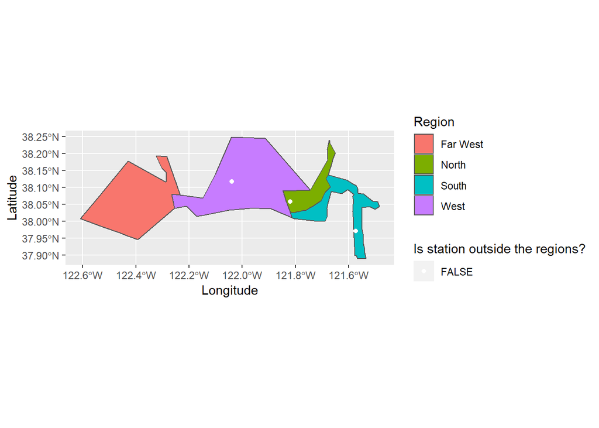

```r
#verified grab totals by comparing to old EMP benthic CPUE file from Betsy Wells
```

## Calculate Annual CPUE for Clams

- Uses only the 1980s stations, and both clam genera

```r
LT_clams_year_noregions <- ben_LT%>%
  filter(Genus %in% c("Potamocorbula", "Corbicula"))%>%
  group_by(Genus, Year) %>%
  summarize(CPUE_Total = mean(CPUE), .groups = "drop") %>%
  pivot_wider(names_from = Genus, values_from = CPUE_Total) %>%
  rename(Corbicula_cpue = Corbicula,
         Potamocorbula_cpue = Potamocorbula)

write.csv(LT_clams_year_noregions, "data/annual_averages/clams_annual_noregions.csv",
          row.names=FALSE)

LT_clams_year_regions <- ben_LT%>%
  filter(Genus %in% c("Potamocorbula", "Corbicula"))%>%
  group_by(Region, Genus, Year) %>%
  summarize(CPUE_Total = mean(CPUE), .groups = "drop") %>%
  pivot_wider(names_from = Genus, values_from = CPUE_Total) %>%
  rename(Corbicula_cpue = Corbicula,
         Potamocorbula_cpue = Potamocorbula)

write.csv(LT_clams_year_regions, "data/annual_averages/clams_annual_regions.csv",
          row.names=FALSE)
```

Export annual station list to data/stations folder

```r
## Use ben_LT so the stations saved here match those used in the annual and annual
## regional datasets saved above.
ben_LT %>%
  rename(Station=StationCode) %>%
  select(Station, Latitude, Longitude) %>%
  distinct() %>%
  mutate(Survey="EMP Benthic") %>%
  write.csv(file=file.path("data/stations/stations_benthic_annual.csv"),
            row.names=FALSE)
```

## Calculate Annual CPUE for Amphipods

- 1980s stations
- For all amphipod data, only include amphipods routinely found in diets per data from the CDFW Diet Study: Ampelisca, Monocorophium, Sinocorophium, Gammarus, Americorophium, Crangonyx, and Hyalella
- Other amphipod species found by the EMP Benthic study are either not found in diets regularly, is rare overall, or found in areas not included in our fish monitoring data (e.g. Eogammarus is typically found in marshes and eaten by Salmon) and likely only caught by EMP due to high flow or transport by vegetation.

```r
LT_amph_year_noregions <- ben_LT%>%
  filter(Genus %in% c("Ampelisca", "Monocorophium", "Sinocorophium", "Americorophium", "Crangonyx", "Gammarus",
                      "Hyalella"))%>%
  group_by(Order_level, Year) %>%
  summarize(across(c(CPUE, BPUE),  mean), .groups = "drop") %>%
  pivot_wider(names_from = Order_level, values_from = c(CPUE, BPUE),
    names_glue = "{Order_level}_{.value}")

write.csv(LT_amph_year_noregions, "data/annual_averages/amphipod_annual_noregions.csv",
          row.names=FALSE)

LT_amph_year_regions <- ben_LT%>%
  filter(Genus %in% c("Ampelisca", "Monocorophium", "Sinocorophium", "Americorophium", "Crangonyx", "Gammarus",
                      "Hyalella"))%>%
  group_by(Region, Order_level, Year) %>%
  summarize(across(c(CPUE, BPUE),  mean), .groups = "drop") %>%
  pivot_wider(names_from = Order_level, values_from = c(CPUE, BPUE),
    names_glue = "{Order_level}_{.value}")

write.csv(LT_amph_year_regions, "data/annual_averages/amphipod_annual_regions.csv",
          row.names=FALSE)
```

## Monthly CPUE for monthly/ regional analysis

Now need to calc monthly CPUE for the stations sampled in the 1990s for the monthly/ regional short term analysis Stations: D41, D41A, C9, D16, D24, D6, P8, D7, D4, D28A

CPUE with 10 ST stations, and limit to 1997 to present since D16 did not start till 1997

```r
ben_ST <- filter(ben, StationCode %in% c(ben_1990, ben_1980) & Year >1996)%>%
  region_assigner(analysis = "monthly")
```

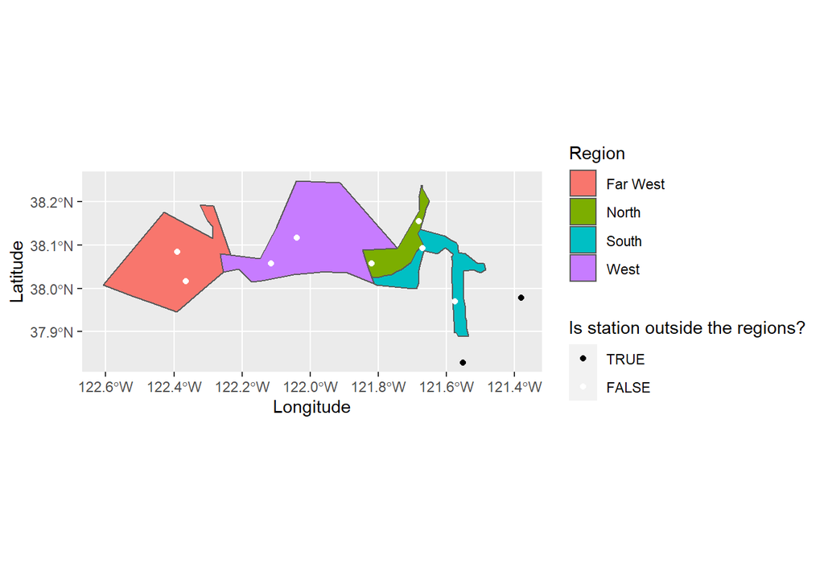

## Calc monthly CPUE for just clams at the 1990 stations

```r
ST_clams_mon <- ben_ST %>%
  filter(Genus %in% c("Potamocorbula", "Corbicula"))%>%
  group_by(Region, Genus, Year, Month) %>%
  summarize(CPUE_Total = mean(CPUE), .groups = "drop") %>%
  pivot_wider(names_from = Genus, values_from = CPUE_Total) %>%
  rename(Corbicula_cpue = Corbicula,
         Potamocorbula_cpue = Potamocorbula)

write.csv(ST_clams_mon, "data/monthly_averages/clams_monthly_regions.csv",
          row.names=FALSE)
```

## Amphipod monthly CPUE

- Monthly analysis also only includes amphipods routinely found in diets per data from the CDFW Diet Study: Ampelisca, Monocorophium, Sinocorophium, Gammarus, Americorophium, Crangonyx, and Hyalella.

```r
ST_amph_mon <- ben_ST%>%
  filter(Genus %in% c("Ampelisca", "Monocorophium", "Sinocorophium", "Americorophium", "Crangonyx", "Gammarus",
                      "Hyalella"))%>%
  group_by(Region, Order_level, Year, Month)%>%
  summarize(across(c(CPUE, BPUE),  mean), .groups = "drop") %>%
  pivot_wider(names_from = Order_level, values_from = c(CPUE, BPUE),
    names_glue = "{Order_level}_{.value}")

write.csv(ST_amph_mon, "data/monthly_averages/amphipod_monthly_regions.csv",
          row.names=FALSE)
```

Export monthly station list to data/stations folder

```r
## Use ben_ST so the stations saved here match those used in the monthly dataset saved
## above.
ben_ST %>%
  rename(Station=StationCode) %>%
  select(Station, Latitude, Longitude) %>%
  distinct() %>%
  mutate(Survey="EMP Benthic") %>%
  write.csv(file=file.path("data/stations/stations_benthic_monthly.csv"),
            row.names=FALSE)
```